# Introduction to Data Science 11372 & 11516 G

Tutorial / Laboratories - Week 11

Welcome to the tutorials and practical laboratory for **Introduction to Data Science**.

# Objectives

The purpose of this week’s tutorial is to practice on:

1. Understanding the data visualisations in R.
2. Reflecting on the generated data visualisation.
3. Understanding the data summarisation of the numerical variables

# Data Visualisation in R

To build a graph in R, you need to specify three components: 1. *Data*: are the records and variables that we need to represent them with the graph to understand the the underneath relationship. 2. *Geometry*: is the plot type, usually represents a function such as (scatterplot, boxplot, barplot, histogram, smooth density, *etc.*) 3. *Aesthetic mapping*: maps the variables into visual cues, such as x-axis, y-axis, size, scale and/or color.

In R, the basic graph template using the `ggplot2` library is as following:

```
ggplot(data = <DATA>)
      <GEOM_FUNCTION>(mapping=aes(<MAPPINGS>))
      <EXTRA_LAYERS>
```

For each of the below exercises, write a different RMarkDown notebook (code and description) to complete the tasks. Then, for each exercise, reflect on the general insights from the generated graphs.

## Exercise 1

```r
df <- data.frame( gender=factor(rep(c("F", "M"), each=200)),
                 weight=round(c(rnorm(200, mean=55, sd=5), rnorm(200, mean=65, sd=5))))
```

Based on the above code, please perform the following steps:

1. Create a graph to visualise the spread of the weight values.
2. Create a graph to show how the weight values are spread across the gender groups.
3. On the generated graph, can you highlights the average weight per each gender group?
4. How can you inspect visually whether the weights of each group include any outliers?
5. what are your insights/findings about the generated analysis?

## Exercise 2

1. Download and import the data called “surveys_complete.csv” from week 11 on Canvas.
2. Generate a graph showing the distribution of the species’ weights based on their id using histogram and boxplot?
3. What are your insights based on using the two methods above (ie, boxplots vs histograms)?

# Data Summarisation – Numerical variables

The numerical data variables can be summarised by extracting various statistical measurements such as mean, median, minimum, maximum, and range of the data values. An effective ways to summarise the numerical variables is to compute the data quantiles. This also can help in spotting the outliers in these variables.

The following figure shows an illustration of one of the common quantiles (i.e. quartile) that presents a way to extract the data median, lower quartile, upper quartile and the Inter quartile range (IQR).

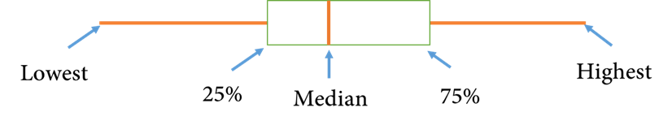

Based on the IQR formula above, we can specify the **outlier** values in the given variable as any data points that fall out of a specifc range. The lowest and the highest values for this range can be computed as follows:

**Lowest = lower quartile - 1.5 * IQR**

**Highest = upper quartile + 1.5 * IQR**

## Exercise 3

Given the following values, (199, 201, 236, 269,271,278,283,291, 301, 303,341):

1. compute the three quartiles and inter-quartile range for this vector.
2. Identify the outlier values, if any.
3. Visualise the box-plot as a graph representation for this vector.